# ggstates, ggfips

Evangeline Reynolds

11/4/2022

## Problem: positioning with SF feels spooky and data prep can feel effortful

W/ ggplot2, we are able to say ‘where’ with x and y. These are positional aesthetics. With SF the ‘where’ is implied with the geometry column. This feels non-declarative and spooky to me.

Also, it often requires pre-processing to work with data you’d like to represent.

When we ask the question ‘where’ in a geographical context, a human being will respond with the name of a region; not coordinates and not a set of coordinates that define a region. Is it possible to create an interface where you define ‘where’ with geographical names or other ids? For example: `aes(country = my_countries_variable)` could be used with a geom/stat like geom_polygon_countries().

See step-by-step:

https://evamaerey.github.io/ggplot2_grammar_guide/geom_sf.html#1

```r
library(tidyverse)

nato_names <- c("Albania", "Belgium", "Bulgaria", "Canada", "Croatia", "Czech Republic", "Denmark", "Estonia", "France", "Germany", "Greece", "Hungary",
                "Iceland", "Italy", "Latvia", "Lithuania", "Luxembourg", "Montenegro", "Netherlands", "Norway", "Poland", "Portugal", "Romania", "Slovakia", "Slovenia", "Spain", "Turkey", "United Kingdom", "United States")
library(gapminder)
gapminder %>%
  filter(year == 2002) %>%
  rename(name = country) ->
gapminder_2002_prepped

rnaturalearth::ne_countries(scale = "medium", returnclass = "sf") %>%
  select(name, pop_est, gdp_md_est,
         continent, geometry) %>%
  filter(name %in% nato_names) %>%
  left_join(gapminder_2002_prepped, by = "name") ->
  nato_countries

ggplot(data = nato_countries) +
  # This part feels spooky to me
  ggplot2::geom_sf(data = nato_countries) +
    aes(fill = lifeExp) +
    scale_fill_viridis_c(option = "magma", direction = -1) +
  ggplot2::coord_sf(xlim = c(-175, 47.5),
           ylim = c(23, 85),
           expand = FALSE) +
  labs(title = "Life Expectancy, 2002",
         subtitle = "NATO Member States",
         fill = "Share of GDP (%)") +
  theme_bw() +
  theme(plot.title =
            element_text(hjust = 0.5)) +
  theme(plot.subtitle =
            element_text(hjust = 0.5))
```

[output not shown]

## A different API?

Here is what I think might be an easy to use API.

```
ggworld(data = gapminder_2002, projection = 'a good one') +
  aes(country = country, # positioning aesthetic
      fill = lifeExp) +
  geom_polygon_country()
```

# Proof of concept? (without SF, and with easy statenames case)

Because of my limited knowledge of SF, let’s start w/ the x and y inputs approach to mapping with ggplot2 and see if we can cook something up.

## Step 00: See how someone gets it done

I was here: https://remiller1450.github.io/s230s19/Intro_maps.html

## Step 0: get it done w/ ggplot2

Look at mapping w/ ggplot2, no sf, we use geom_polygon and the x, y and group aesthetics). It is not very efficient (lots of redundant info in the ), but we won’t worry about that for this demonstration. A little rewrite to get inspired.

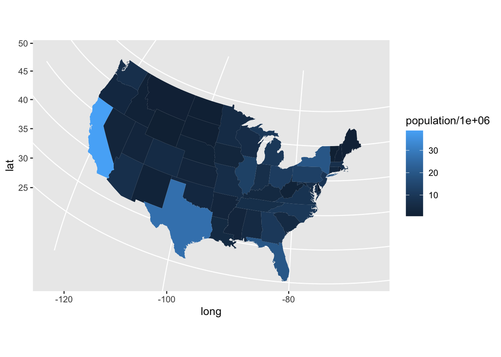

```r
library(ggplot2)
library(dplyr)
library(maps)
MainStates <- map_data("state")
StatePopulation <- read.csv("https://raw.githubusercontent.com/ds4stats/r-tutorials/master/intro-maps/data/StatePopulation.csv", as.is = TRUE)

MergedStates <- inner_join(MainStates, StatePopulation, by = "region")

StatePopulation %>% # becomes ggus()
  right_join(MainStates) %>% # becomes ggus()
  ggplot() + # becomes ggus()
  geom_polygon() + # becomes geom_polygon state
  aes(x = long, # becomes state = region
      y = lat, # becomes state = region
      group = group, # becomes state = region
      fill = population/1000000) +
  coord_map(projection = "orthographic",
            orientation = c(41, -74, 0))
```

# Step 1: compute function and test

```r
library(maps)
MainStates <- map_data("state")
# AllCounty <- map_data("county")
# MainCities <- filter(us.cities, long>=-130)

MainStates %>%
  rename(state = region) %>%
  rename(which_polygon = group) ->
continuous_states

continuous_states %>%
  count(state, which_polygon) %>%
  sample_n(10)
```

```
##           state which_polygon    n
## 1  rhode island            46   66
## 2      new york            35  290
## 3    new mexico            33   78
## 4          ohio            42  238
## 5         texas            50 1088
## 6          utah            51   59
## 7     wisconsin            62  388
## 8      delaware             7   94
## 9    new jersey            32  205
## 10     oklahoma            43  284
```

```r
StatePopulation <- read.csv("https://raw.githubusercontent.com/ds4stats/r-tutorials/master/intro-maps/data/StatePopulation.csv", as.is = TRUE)

compute_state <- function(data, scales){

  data %>%
    inner_join(continuous_states, multiple = "all") %>%
    mutate(x = long, y = lat) %>%
    arrange(order) %>%
    # mutate(group = paste(group, ".", which_polygon)) %>%
    # group_by(which_polygon) %>%
    data.frame()

}

StatePopulation %>%
  rename(state = region) %>%
  mutate(group = row_number()) %>%
  compute_state() ->
computed
computed %>% sample_n(30)
```

```
##             state population elect_votes group       long      lat
## 1        new york   19746227          29    32  -76.19193 44.02608
## 2      california   38802500          55     5 -120.40134 34.46341
## 3           texas   26956958          38    43 -100.13583 28.14942
## 4        illinois   12880580          20    13  -88.45322 37.13340
## 5           texas   26956958          38    43  -97.07624 28.20671
## 6         florida   19893297          29     9  -86.37339 30.43552
## 7           texas   26956958          38    43  -96.41161 28.74529
## 8        new york   19746227          29    32  -76.97688 43.25258
## 9   west virginia    1850326           5    48  -80.62089 40.50239
## 10      minnesota    5457173          10    23  -92.68738 48.47796
## 11     new jersey    8938175          14    30  -74.11782 39.94662
## 12      tennessee    6549352          11    42  -83.42838 35.62078
## 13  west virginia    1850326           5    48  -80.55787 40.63990
## 14     new jersey    8938175          14    30  -75.39552 39.36220
```

[output cut: 47 more lines]

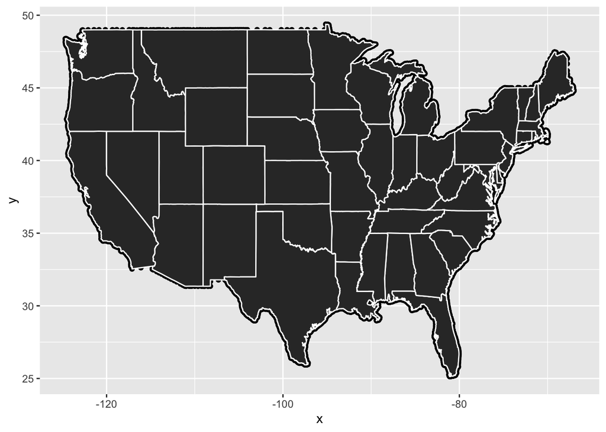

```r
computed %>%
  ggplot() +
  aes(x = x, y = y) +
  geom_point() +
  geom_polygon(color = "white") +
  aes(group = which_polygon)
```

```r
my_setup_data <- function(data, params){
                                    if(data$group[1] == -1){
                                      nrows <- nrow(data)
                                      data$group <- seq_len(nrows)
                                    }
                                    data
}
```

# Step 2: pass to ggproto

```r
StatPolygonstate <- ggplot2::ggproto(`_class` = "StatPolygonstate",
                                  `_inherit` = ggplot2::Stat,
                                  required_aes = c("state"),
                                  # setup_data = my_setup_data,
                                  compute_panel = compute_state,
                                  default_aes = aes(group = after_stat(which_polygon))
                                  )
```

# Step 3: write geom_* function

```r
geom_polygon_state <- function(
  mapping = NULL,
  data = NULL,
  position = "identity",
  na.rm = FALSE,
  show.legend = NA,
  inherit.aes = TRUE, ...) {
  ggplot2::layer(
    stat = StatPolygonstate,  # proto object from step 2
    geom = ggplot2::GeomPolygon,  # inherit other behavior
    data = data,
    mapping = mapping,
    position = position,
    show.legend = show.legend,
    inherit.aes = inherit.aes,
    params = list(na.rm = na.rm, ...)
  )
}
```

# step 4: test geom_* function, celebrate!

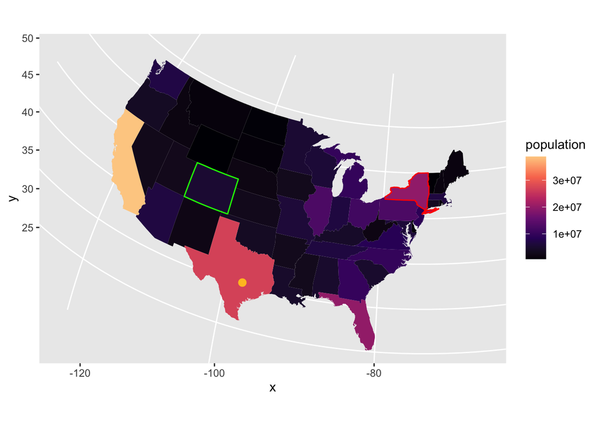

```r
StatePopulation %>% #count(region)
  mutate(region = region %>% stringr::str_trim() %>% as.factor()) %>%
  ggplot(data = .) +
  aes(state = region, # state indicates position instead of x and y
      fill = population) +
  geom_polygon_state() +
  coord_map(projection = "orthographic",
            orientation = c(41, -74, 0)) +
  geom_polygon_state(data = . %>%
                       filter(region == "new york"),
                     color = "red" ) +
  geom_polygon_state(data = . %>%
                       filter(region == "colorado"),
                     color = "green" ) +
  scale_fill_viridis_c(option = "magma", end = .9) +
  ggstamp::stamp_point(y = 30.2, x = -97.7,
                       color = "goldenrod1",
                       size = 2)
```

# Step 5: What’s not working and taking a break.

1. Solved! “Not sure what’s going on w/ merge so that we only get the 4 states,” now much better! there was a grouping variable in the polygons data set named ‘group’ - this really messed with things because ggplot2 uses that var internally. We renamed!
2. state = var, var must be factor (not character). I’ve seen this before and I’d like that not to be the case, but fine for now.
3. There are subregions. You can see the tell tail-signs. Seems like setup_data should help w/ group management
4. Take a break!

# 0 County - ggfips?

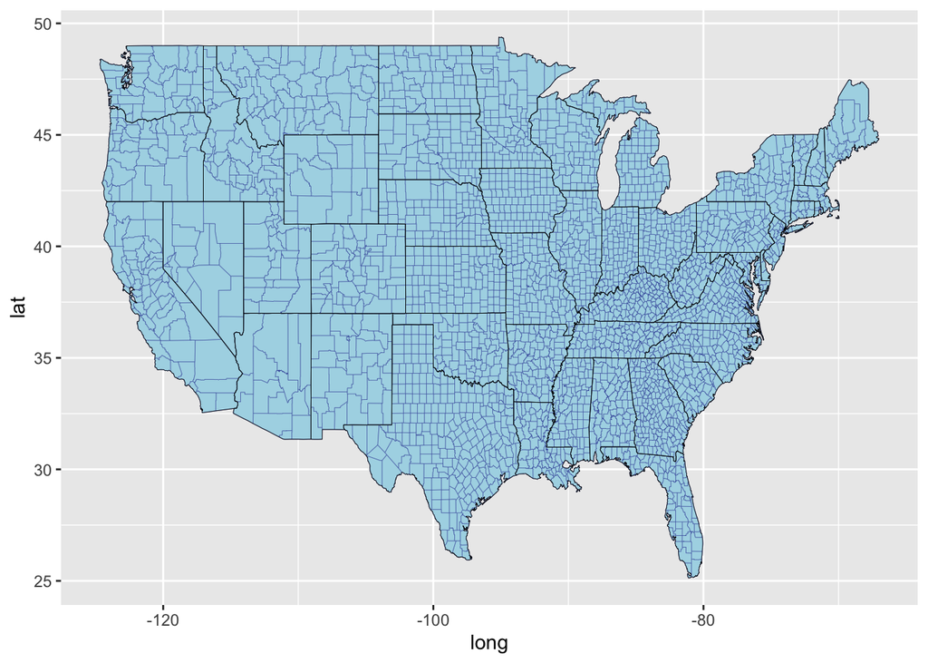

```r
AllCounty <- map_data("county")

ggplot() + geom_polygon(data=AllCounty, aes(x=long, y=lat, group=group),
                color="darkblue", fill="lightblue", size = .1 ) +

          geom_polygon( data=MainStates, aes(x=long, y=lat, group=group),
                color="black", fill="lightblue",  size = .15, alpha = .3)
```

# Circle pack seems similar…

https://evamaerey.github.io/mytidytuesday/2022-05-28-circle-pack/circle_pack_stipple.html